# Identificando coordenadas outliers com o pacote CoordinateCleaner

Como exemplo, usaremos os registros de Apocynaceae do SpeciesLink (https://specieslink.net/).

### Instalação e carregamento dos pacotes

- **openxlsx** (Schauberger *et al*., 2020): https://ycphs.github.io/openxlsx/index.html
- **raster** (Hijmans, 2021): https://CRAN.R-project.org/package=raster
- **rgeos** (Bivand & Colin Rundel, 2021): https://CRAN.R-project.org/package=rgeos
- **CoordinateCleaner** (Zizka *et al*., 2019): https://github.com/ropensci/CoordinateCleaner

Instalamos os pacotes com o comando `install.packages()`:

```r
install.packages(c("openxlsx", "raster", "rgeos", "CoordinateCleaner"), repos="http //cran.us.r-project.org")
```

Carregamos os pacotes com o comando `library()`:

```r
library("openxlsx")
library("raster")
library("rgeos")
library("CoordinateCleaner")
```

### Setup do ambiente de trabalho e carregamento dos dados

Vamos definir o diretório de trabalho, onde estará a *planilha* baixada do **SpeciesLink**. Para isso, usamos a função `set.wd()`.

```r
setwd("/Users/jdvidal/Desktop/INCT/Dados_filtrados_final/")
```

Vamos usar a função `read.xlsx()` para ler as planilha.

```r
records_splink <- read.xlsx("/Users/jdvidal/Desktop/INCT/Dados_filtrados_final/SpeciesLink_valid_names.xlsx")
records_gbif <- read.xlsx("/Users/jdvidal/Desktop/INCT/Dados_filtrados_final/GBIF_valid_names.xlsx")
```

### Preparando o conjunto de dados

Vamos combinar os dois datasets. Para isso, precisamos verificar se os códigos de coleção e número de catálogo das entradas da planilha do **GBIF** constam na planilha do **SpeciesLink**. Faremos isto criando um campo chamado *$barcode*, que seja a combinação dos código de coleção e número de catálogo, usando a função `paste0()`.

```r
records_splink$barcode <- paste0(records_splink$collectioncode,records_splink$catalognumber)
records_gbif$barcode <- paste0(records_gbif$collectionCode,records_gbif$catalogNumber)
```

E selecionamos apenas aquelas entradas com números de catálogo no *recods_gbif* que não estão no *records_splink*.

```r
records_gbif_exclusives <- records_gbif[!records_gbif$barcode%in%records_splink$barcode,]
```

Podemos agora padronizar os nomes de colunas dos data.frames. Vamos também criar uma coluna dizendo a origem dos dados (*$source*) e uma coluna *$Counts*, necessária para a análise posterior de riqueza.

```r
# GBIF
apocyn_BR_GBIF <- data.frame(Species=paste0(records_gbif_exclusives$genus_flora, " ", records_gbif_exclusives$specific_epithet_flora),
                        Longitude=records_gbif_exclusives$decimalLongitude,
                        Latitude=records_gbif_exclusives$decimalLatitude,
                        Counts=1, source="GBIF")

# SpeciesLink
apocyn_BR_splink <- data.frame(Species=paste0(records_splink$genus_flora, " ", records_splink$specific_epithet_flora),
                        Longitude=records_splink$longitude,
                        Latitude=records_splink$latitude,
                        Counts=1, source="SpeciesLink")
```

Finalmente, combinamos os dois data.frames com `rbind()`.

```r
records <- rbind.data.frame(apocyn_BR_GBIF, apocyn_BR_splink)
```

Os valores de coordenadas nas colunas *$Latitude* e *$Longitude* estão sendo interpretados como texto. Para convertê-los para números, usamos a função `as.numeric()`.

```r
records$Latitude <- as.numeric(records$Latitude)
records$Longitude <- as.numeric(records$Longitude)
```

Vamos nos certificar de usar apenas dados que possuam informação geográfica. Para isso, usamos `complete.cases()` para selecionar apenas linhas cujos valores estão completos para a coluna “latitude”.

```r
records <- records[complete.cases(records$Latitude),]
```

### Filtragem com a função clean_coordinates()

Nesta etapa, filtraremos os dados para excluir outliers geográficos utilizando o CoordinateCleaner. A função principal do pacote é a função `clean_coordinates()`. Verifique os argumentos e todas as possibilidades de opções no arquivo de ajuda (´?clean_coordinates´). Existem diversas opções que podem ser passadas ao argumento tests. Neste tutorial usaremos “capitals”, “centroids”, “equal”, “gbif”, “institutions”, e “seas”. Essa função leva três argumentos, sendo o primeiro deles o objeto data.frame com as ocorrências, o segundo argumento *lon* referente ao nome da coluna contendo os valores de longitude e o terceiro argumento *lat*, cujo valor corresponde ao nome da coluna contendo os valores de latitude.

```r
apocyn_BR_clean <- clean_coordinates(
  records,
  lon = "Longitude",
  lat = "Latitude",
  species = "Species",
  tests = c("capitals", "centroids", "equal", "gbif", "institutions","seas"),
  capitals_rad = 10000,
  centroids_rad = 1000,
  centroids_detail = "both",
  inst_rad = 100,
  outliers_method = "quantile",
  outliers_mtp = 5,
  outliers_td = 1000,
  outliers_size = 7,
  range_rad = 0,
  zeros_rad = 0.5,
  seas_scale = 50,
  value = "clean",
  verbose = TRUE,
  report = FALSE
)
```

```
## Testing coordinate validity
```

```
## Flagged 0 records.
```

```
## Testing equal lat/lon
```

```
## Flagged 0 records.
```

```
## Testing country capitals
```

```
## Flagged 909 records.
```

```
## Testing country centroids
```

```
## Flagged 240 records.
```

```
## Testing sea coordinates
```

```
## Flagged 1331 records.
```

```
## Testing GBIF headquarters, flagging records around Copenhagen
```

```
## Flagged 0 records.
```

```
## Testing biodiversity institutions
```

```
## Flagged 125 records.
```

```
## Flagged 2590 of 64378 records, EQ = 0.04.
```

### Filtrando manualmente o centróide geográfico do Brasil.

Vamos checar manualmente outliers para o centróide *-52.8731, -10.8339*, que não foi capturado pelo CoordinateCleaner. Podemos verificar que muitos dados estão concentrados neste ponto se inspercionarmos a moda dos registros. Para isso, criamos manualmente a função `getmode()` para achar a moda de um vetor.

```r
getmode <- function(v) {
  uniqv <- unique(v)
  uniqv[which.max(tabulate(match(v, uniqv)))]
}
```

Ao usarmos essa função no nosso banco de dados, encontramos o problema.

```r
getmode(apocyn_BR_clean$Longitude)
```

```
## [1] -52.8731
```

```r
getmode(apocyn_BR_clean$Latitude)
```

```
## [1] -10.8339
```

Podemos usar um teste lógico para excluir entradas com estes valores para lat-lon.

```r
apocyn_BR_clean_filtered <- apocyn_BR_clean[apocyn_BR_clean$Longitude!=getmode(apocyn_BR_clean$Longitude)&apocyn_BR_clean$Latitude!=getmode(apocyn_BR_clean$Latitude),]
```

### Removendo centróides de estados brasileiros

Usamos a função `gCentroid()` do *rgeos* com o argumento `byid=TRUE` para calcular os centróides de todos os polígonos em um shapefile.

```r
trueCentroids = gCentroid(states, byid=TRUE)
```

Plotamos para inspecionar.

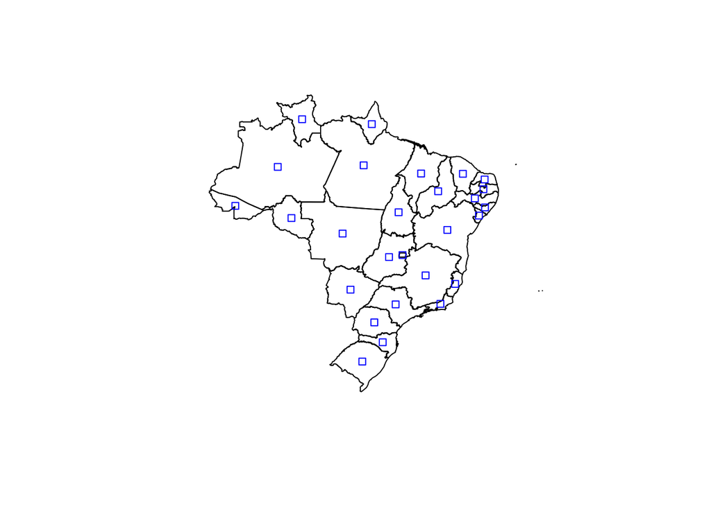

```r
plot(states)
points(apocyn_BR_clean_filtered, cex=0.5, col="red")
points(trueCentroids,pch=22, col="blue")
```

Criamos agora um buffer ao redor dos pontos com a função `buffer()` do pacote *raster*. Esta função leva um objeto espacial como primero argumento (os pontos gerados na etapa anterior: `trueCentroids`) e um valor de distância no segundo argumento. Como utilizamos 10 km (10000) na etapa do CoordinateCleaner, manteremos este valor aqui.

```r
buffer <- buffer(trueCentroids, 10000)
```

Precisamos atribuir coordenadas o objeto com nossos registros. Para isso, usamos a função `coordinates()` e declaramos que as colunas *longitude* e *latitude* correspondem aos valores de coordenadas x e y com o argumento `~longitude+latitude`.

```r
coordinates(apocyn_BR_clean_filtered) <- ~Longitude+Latitude
```

Atribuímos o mesmo CRS (coordinate reference system) aos pontos e ao buffer com a função `crs()`.

```r
crs(apocyn_BR_clean_filtered) <- crs(buffer)
```

Selecionamos os pontos dentro dos buffers.

```r
centroid_records <- apocyn_BR_clean_filtered[buffer,]
```

Convertemos novamente os objetos para data.frame com a função `as.data.frame()`.

```r
centroid_records <- as.data.frame(centroid_records)
apocyn_BR_clean_filtered <- as.data.frame(apocyn_BR_clean_filtered)
```

E subselecionamos os registros que não tenham caído dentro do buffer.

```r
apocyn_BR_clean_filtered_stcentroids <- apocyn_BR_clean_filtered[!rownames(apocyn_BR_clean_filtered)%in%rownames(centroid_records),]
```

Checamos se os resultados estão coerentes comparando as quantidades de registros antes e depois da análise.

```r
(nrow(apocyn_BR_clean_filtered)-nrow(centroid_records))==nrow(apocyn_BR_clean_filtered_stcentroids)
```

```
## [1] TRUE
```

Salvamos o resultado.

```r
write.xlsx(apocyn_BR_clean_filtered_stcentroids, "/Users/jdvidal/Desktop/INCT/Relatório/Planilha_final_filtradas.xlsx", overwrite = TRUE)
```